# General Assembly DSI Project 3 in R

Isaac Moore

```r
setwd("~/Google Drive/data_science/general_assembly/Projects/DSI_SM_Project3")
```

Loading packages

```r
library("tidyverse", lib.loc="/Library/Frameworks/R.framework/Versions/3.3/Resources/library")
library(caret)
library(readr)
library(lubridate)
library(reshape2)
```

```r
# Load the data into a DataFrame
raw_data <- read_csv("Iowa_Liquor_sales_sample_10pct.csv")
```

```r
# Create a copy of the data
df <- raw_data
glimpse(df)
```

```
Observations: 270,955
Variables: 18
$ Date                  <chr> "11/04/2015", "03/02/2016", "02/11/2016", "02/03/2016"...
$ Store Number          <int> 3717, 2614, 2106, 2501, 3654, 2569, 2596, 3456, 4757, ...
$ City                  <chr> "SUMNER", "DAVENPORT", "CEDAR FALLS", "AMES", "BELMOND...
$ Zip Code              <chr> "50674", "52807", "50613", "50010", "50421", "52402", ...
$ County Number         <dbl> 9, 82, 7, 85, 99, 57, 90, 17, 77, 6, 77, 62, 82, 56, 5...
$ County                <chr> "Bremer", "Scott", "Black Hawk", "Story", "Wright", "L...
$ Category              <dbl> 1051100, 1011100, 1011200, 1071100, 1031080, 1041100, ...
$ Category Name         <chr> "APRICOT BRANDIES", "BLENDED WHISKIES", "STRAIGHT BOUR...
$ Vendor Number         <int> 55, 395, 65, 395, 297, 205, 85, 65, 370, 65, 65, 55, 6...
$ Item Number           <int> 54436, 27605, 19067, 59154, 35918, 31473, 52806, 10628...
$ Item Description      <chr> "Mr. Boston Apricot Brandy", "Tin Cup", "Jim Beam", "1...
$ Bottle Volume (ml)    <int> 750, 750, 1000, 1750, 1750, 1750, 750, 1750, 750, 1000...
$ State Bottle Cost     <chr> "$4.50", "$13.75", "$12.59", "$9.50", "$7.20", "$13.32...
$ State Bottle Retail   <chr> "$6.75", "$20.63", "$18.89", "$14.25", "$10.80", "$19....
$ Bottles Sold          <int> 12, 2, 24, 6, 12, 6, 3, 2, 4, 2, 6, 6, 1, 12, 12, 4, 4...
$ Sale (Dollars)        <chr> "$81.00", "$41.26", "$453.36", "$85.50", "$129.60", "$...
$ Volume Sold (Liters)  <dbl> 9.00, 1.50, 24.00, 10.50, 21.00, 10.50, 2.25, 3.50, 3....
$ Volume Sold (Gallons) <dbl> 2.38, 0.40, 6.34, 2.77, 5.55, 2.77, 0.59, 0.92, 0.79, ...
```

### Explore the data

Perform some exploratory statistical analysis and make some plots, such as histograms of transaction totals, bottles sold, etc.

```r
cols <- colnames(df)
cols <- tolower(gsub(" ", "_", cols))
cols <- gsub("\\(","", cols)
colnames(df) <- gsub(")","", cols)
colnames(df)
```

```
 [1] "date"                "store_number"        "city"
 [4] "zip_code"            "county_number"       "county"
 [7] "category"            "category_name"       "vendor_number"
[10] "item_number"         "item_description"    "bottle_volume_ml"
[13] "state_bottle_cost"   "state_bottle_retail" "bottles_sold"
[16] "sale_dollars"        "volume_sold_liters"  "volume_sold_gallons"
```

```r
# Convert dates
df$date <-  mdy(df$date)
class(df$date)
```

```
[1] "Date"
```

```r
# Remove $ from items in columns
df$state_bottle_cost <- as.double(gsub("\\$", "", df$state_bottle_cost))
df$state_bottle_retail <- as.double(gsub("\\$", "", df$state_bottle_retail))
df$sale_dollars <- as.double(gsub("\\$", "", df$sale_dollars))
```

```r
glimpse(df)
```

```
Observations: 270,955
Variables: 16
$ date                <date> 2015-11-04, 2016-03-02, 2016-02-11, 2016-02-03, 2015-08...
$ store_number        <int> 3717, 2614, 2106, 2501, 3654, 2569, 2596, 3456, 4757, 43...
$ city                <chr> "SUMNER", "DAVENPORT", "CEDAR FALLS", "AMES", "BELMOND",...
$ zip_code            <chr> "50674", "52807", "50613", "50010", "50421", "52402", "5...
$ county              <chr> "Bremer", "Scott", "Black Hawk", "Story", "Wright", "Lin...
$ category            <dbl> 1051100, 1011100, 1011200, 1071100, 1031080, 1041100, 10...
$ category_name       <chr> "APRICOT BRANDIES", "BLENDED WHISKIES", "STRAIGHT BOURBO...
$ vendor_number       <int> 55, 395, 65, 395, 297, 205, 85, 65, 370, 65, 65, 55, 65,...
$ item_description    <chr> "Mr. Boston Apricot Brandy", "Tin Cup", "Jim Beam", "180...
$ bottle_volume_ml    <int> 750, 750, 1000, 1750, 1750, 1750, 750, 1750, 750, 1000, ...
$ state_bottle_cost   <dbl> 4.50, 13.75, 12.59, 9.50, 7.20, 13.32, 6.66, 15.75, 11.4...
$ state_bottle_retail <dbl> 6.75, 20.63, 18.89, 14.25, 10.80, 19.98, 9.99, 23.63, 17...
$ bottles_sold        <int> 12, 2, 24, 6, 12, 6, 3, 2, 4, 2, 6, 6, 1, 12, 12, 4, 48,...
$ sale_dollars        <dbl> 81.00, 41.26, 453.36, 85.50, 129.60, 119.88, 29.97, 47.2...
$ volume_sold_liters  <dbl> 9.00, 1.50, 24.00, 10.50, 21.00, 10.50, 2.25, 3.50, 3.00...
$ volume_sold_gallons <dbl> 2.38, 0.40, 6.34, 2.77, 5.55, 2.77, 0.59, 0.92, 0.79, 0....
```

```r
summary(df)
```

```
      date             store_number      city             zip_code
 Min.   :2015-01-05   Min.   :2106   Length:270955      Length:270955
 1st Qu.:2015-05-04   1st Qu.:2604   Class :character   Class :character
 Median :2015-08-19   Median :3722   Mode  :character   Mode  :character
 Mean   :2015-08-20   Mean   :3590
 3rd Qu.:2015-12-10   3rd Qu.:4378
 Max.   :2016-03-31   Max.   :9023

    county             category       category_name      vendor_number
 Length:270955      Min.   :1011100   Length:270955      Min.   : 10.0
 Class :character   1st Qu.:1012200   Class :character   1st Qu.:115.0
 Mode  :character   Median :1031200   Mode  :character   Median :260.0
                    Mean   :1043888                      Mean   :256.4
                    3rd Qu.:1062310                      3rd Qu.:380.0
                    Max.   :1701100                      Max.   :978.0
                    NA's   :68
 item_description   bottle_volume_ml state_bottle_cost state_bottle_retail
 Length:270955      Min.   :  50.0   Min.   :  0.890   Min.   :  1.34
 Class :character   1st Qu.: 750.0   1st Qu.:  5.500   1st Qu.:  8.27
 Mode  :character   Median : 750.0   Median :  8.000   Median : 12.27
                    Mean   : 924.8   Mean   :  9.773   Mean   : 14.68
                    3rd Qu.:1000.0   3rd Qu.: 11.920   3rd Qu.: 17.88
                    Max.   :6000.0   Max.   :425.000   Max.   :637.50

  bottles_sold       sale_dollars      volume_sold_liters volume_sold_gallons
 Min.   :   1.000   Min.   :    1.34   Min.   :   0.100   Min.   :  0.030
 1st Qu.:   2.000   1st Qu.:   30.45   1st Qu.:   1.500   1st Qu.:  0.400
 Median :   6.000   Median :   70.56   Median :   5.250   Median :  1.390
 Mean   :   9.871   Mean   :  128.90   Mean   :   8.981   Mean   :  2.373
 3rd Qu.:  12.000   3rd Qu.:  135.00   3rd Qu.:  10.500   3rd Qu.:  2.770
 Max.   :2508.000   Max.   :36392.40   Max.   :2508.000   Max.   :662.540
```

Category contains 68 NA’s

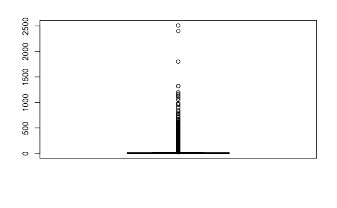

```r
boxplot(df$bottles_sold)
```

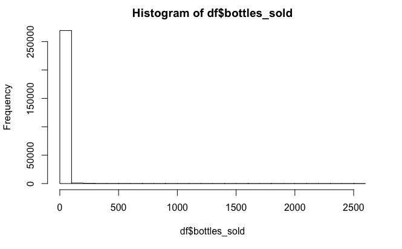

```r
hist(df$bottles_sold)
```

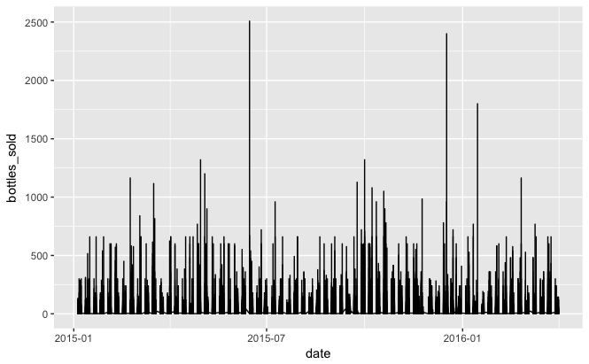

```r
ggplot(df, aes(date, bottles_sold)) + geom_line()
```

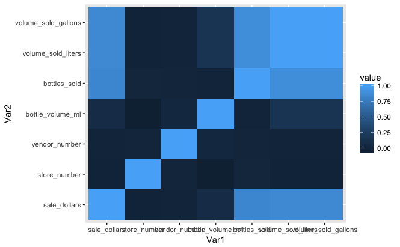

```r
df_numeric <- df %>% select(c(sale_dollars, store_number, vendor_number, bottle_volume_ml, bottles_sold, volume_sold_liters, volume_sold_gallons))
# library(d3heatmap)
# d3heatmap(df_numeric, scale = "column")
cormat <- round(cor(df_numeric),2)
melted_cormat <- melt(cormat)
ggplot(data = melted_cormat, aes(x=Var1, y=Var2, fill=value)) +
  geom_tile()
```

d3heatmap takes too long to generate a heatmap. Using ggplot takes a lot less time.

### Mine the data

Now you are ready to compute the variables you will use for your regression from the data. For example, you may want to compute total sales per store from Jan to March of 2015, mean price per bottle, etc. Refer to the readme for more ideas appropriate to your scenario.

```r
# total sales per store from Jan to March of 2015
a <- df %>% filter(date >= "2015-1-1" & date <= "2015-3-31") %>% group_by(store_number) %>% summarise(total_sales = sum(sale_dollars)) %>% arrange(desc(total_sales))
a
```

| store_number | total_sales |
| --- | --- |
| 2633 | 207012.08 |
| 4829 | 203842.07 |
| 3385 | 105921.75 |
| 3952 | 85840.78 |
| 3420 | 85542.78 |
| 2512 | 82117.82 |
| 3814 | 56443.62 |
| 3447 | 54233.74 |
| 3820 | 51033.86 |
| 3773 | 48574.94 |

[output cut: 990 more lines]

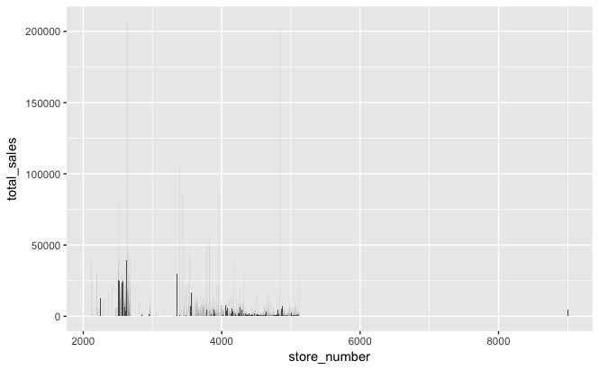

```r
ggplot(a, aes(store_number, total_sales)) +
               geom_bar(stat = "identity")
```

```r
# mean price per bottle
mean(df$state_bottle_cost)
```

```
[1] 9.773281
```

```r
mean(df$state_bottle_retail)
```

```
[1] 14.67576
```

```r
b <- df %>% filter(date >= "2015-1-1" & date <= "2015-3-31") %>% group_by(county) %>% summarise(total_sales = sum(sale_dollars)) %>% arrange(desc(total_sales))
b
```

| county | total_sales |
| --- | --- |
| Polk | 1340375.51 |
| Linn | 574464.38 |
| Scott | 418415.27 |
| Black Hawk | 340867.08 |
| Johnson | 322143.10 |
| Pottawattamie | 232750.24 |
| Woodbury | 230760.16 |
| Story | 203131.69 |
| Dubuque | 190977.13 |
| Cerro Gordo | 111299.13 |

[output cut: 90 more lines]

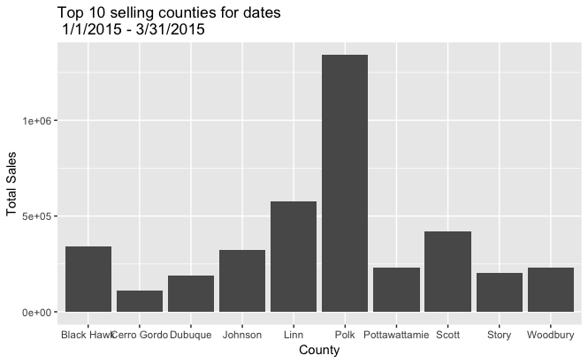

```r
ggplot(head(b, n = 10), aes(county, total_sales)) +
        geom_bar(stat = "identity") +
        labs(title = "Top 10 selling counties for dates \n 1/1/2015 - 3/31/2015", x = "County", y = "Total Sales")
```

```r
# Total sales in 2015 per store
sales_2015 <- df %>% filter(date >= "2015-1-1" & date <= "2015-12-31") %>%
        group_by(store_number) %>%
                summarise(total_sales = sum(sale_dollars))
head(sales_2015)
```

| store_number | total_sales |
| --- | --- |
| 2106 | 146326.22 |
| 2113 | 9310.22 |
| 2130 | 111871.43 |
| 2152 | 7721.08 |
| 2178 | 24324.18 |
| 2190 | 121689.06 |

```r
# Total sales in 2016 per store
sales_2016 <- df %>% filter(date >= "2016-1-1" & date <= "2016-12-31") %>%
        group_by(store_number) %>%
                summarise(total_sales = sum(sale_dollars))
head(sales_2016)
```

| store_number | total_sales |
| --- | --- |
| 2106 | 30523.75 |
| 2113 | 2065.90 |
| 2130 | 27856.11 |
| 2152 | 1376.43 |
| 2178 | 5588.50 |
| 2190 | 34515.69 |

```r
sales_1516 <- left_join(sales_2015, sales_2016, by = "store_number")
colnames(sales_1516) <- c("store_number", "total_15", "total_16")
sales_1516$total <- sales_1516$total_15 + sales_1516$total_16
arrange(sales_1516, desc(total))
```

| store_number | total_15 | total_16 | total |
| --- | --- | --- | --- |
| 2633 | 1000783.30 | 219551.79 | 1220335.09 |
| 4829 | 878812.70 | 210340.17 | 1089152.87 |
| 2512 | 419746.83 | 112518.79 | 532265.62 |
| 3385 | 441983.55 | 64605.54 | 506589.09 |
| 3420 | 352020.66 | 50555.40 | 402576.06 |
| 3952 | 333311.98 | 59139.45 | 392451.43 |
| 3814 | 247417.42 | 63118.98 | 310536.40 |
| 3773 | 232460.41 | 66202.79 | 298663.20 |
| 3354 | 240365.94 | 55227.36 | 295593.30 |
| 2670 | 227442.71 | 54701.99 | 282144.70 |

[output cut: 990 more lines]

### Build your models

Using scikit-learn or statsmodels, build the necessary models for your scenario. Evaluate model fit.  
*I’ll be using the base lm (Linear model) function and the Caret package to make my predictions*  
Use the data from 2015 to make a linear model using as many variables as you find useful to predict the yearly sales of each store. You must use the sales from Jan to March per store as one of your variables.

```r
# Creating a dataframe for modeling and adding Sales from Jan to Mar as a column
#detach(package:plyr)
modeler <- df %>% filter(date >= "2015-1-1" & date <= "2015-3-31") %>%
        group_by(store_number) %>%
        mutate(sale_dollars = sum(sale_dollars))
modeler <- select(-c("city", "county", "category_name", "item_description"))
```

```
Error in -c("city", "county", "category_name", "item_description") :
  invalid argument to unary operator
```

```r
set.seed(1987)
index <- sample(1:nrow(df_numeric), size=0.2*nrow(df))
test <-  df_numeric[index, ]
train = df_numeric[-index, ]
model <- lm(sale_dollars ~ ., data = train)
print(model)
```

```
Call:
lm(formula = sale_dollars ~ ., data = train)

Coefficients:
        (Intercept)         store_number        vendor_number     bottle_volume_ml
          3.280e+01           -5.329e-03           -2.104e-02            2.916e-03
       bottles_sold   volume_sold_liters  volume_sold_gallons
          5.350e+00           -1.885e+02            7.408e+02
```

```r
summary(model)
```

```
Call:
lm(formula = sale_dollars ~ ., data = train)

Residuals:
    Min      1Q  Median      3Q     Max
-9112.3   -32.1    -9.6    15.5 15735.8

Coefficients:
                      Estimate Std. Error t value Pr(>|t|)
(Intercept)          3.280e+01  1.908e+00  17.197  < 2e-16 ***
store_number        -5.329e-03  4.091e-04 -13.027  < 2e-16 ***
vendor_number       -2.104e-02  2.742e-03  -7.672 1.70e-14 ***
bottle_volume_ml     2.916e-03  9.197e-04   3.171  0.00152 **
bottles_sold         5.350e+00  3.574e-02 149.683  < 2e-16 ***
volume_sold_liters  -1.885e+02  3.756e+01  -5.019 5.20e-07 ***
volume_sold_gallons  7.408e+02  1.422e+02   5.211 1.88e-07 ***
---
Signif. codes:  0 ‘***’ 0.001 ‘**’ 0.01 ‘*’ 0.05 ‘.’ 0.1 ‘ ’ 1

Residual standard error: 179.9 on 216757 degrees of freedom
Multiple R-squared:  0.7522,    Adjusted R-squared:  0.7522
F-statistic: 1.097e+05 on 6 and 216757 DF,  p-value: < 2.2e-16
```

```r
# Make Predictions
p <- predict(model, test)
```

```r
# Calculate the error in the model
error <- p - test$sale_dollars
# RMSE (Root Mean Squared Error) - The average amount of error we can expect when making predictions on sale_dollars
sqrt(mean(error^2))
```

```
[1] 240.992
```

```r
library(caret)
model <- train(
  sale_dollars ~ ., df_numeric,
  method = "lm",
  trControl = trainControl(
    method = "cv", number = 5,
    verboseIter = TRUE
  )
)
model
```

```
Linear Regression

270955 samples
     6 predictor

No pre-processing
Resampling: Cross-Validated (5 fold)
Summary of sample sizes: 216764, 216764, 216763, 216765, 216764
Resampling results:

  RMSE     Rsquared
  194.429  0.7417729

Tuning parameter 'intercept' was held constant at a value of TRUE
```